# Summary Week 10

Most studies correlating the native to exotic species richness have found negative and positive correlations at small and large scales, respectively. Researchers have proposed that at smaller scales native species competitively exclude exotic sepcies. Conversely, at larger scales researachers have proposed environmental effects mask the negative effects of native species richness on exotics, leading to a positive correlation.

Fridley et al. (2004) proposed that the spatial relationships could not be due to biological interactions between native and exotics. Instead, the spatial correlation may be due to chance. As such, they tested two datasets relating native to exotic species against a null distribution, and found that the null distrubution fit both datasets well. As such, they concluded that native species may have no biological influence on exotic species, and the patterns seen at various spatial scales may be due primarily stastical artifacts (i.e random or chance).

Two main objectives: 1) Use the code published with Fridley et al. (2004) to recreate the null distribution 2) Test Emily's dataset of exotic: native species to determine whether the null distribution fits her dataset

Objective 1:

```r
###### Defining all variables

reps <- 100  #Number of replicates for each sample size

samps <- c(5, 10, 20, 50, 100, 800)  #sample sizes, in number of represented individuals

pool.range <- c(20, 100)

NEprop <- c(0.75, 0.15, 0.1)  #proportion of, respectively, natives, exotics, and bare spaces in pool (totals to 1)

tot.pool <- round(runif(reps, pool.range[1], pool.range[2]))  #randomly generate [reps]-length vector of total pool sizes

# make a output matrix to fill all the differentsimulations (why we have a
# third dimension, so that it does not replace the earlier matrix)

output <- array(0, dim = c(2, length(samps), reps))

# loop to simulate the matrixes

for (j in 1:reps) {

    # determine pool composition for replicate

    natives <- paste("N", c(1:round(NEprop[1] * tot.pool[j])))  #list of native species

    exotics <- paste("E", c(1:round(NEprop[2] * tot.pool[j])))  #list of exotic species

    zeros <- paste("Z", c(1:round(NEprop[3] * tot.pool[j])))
    # list of free spaces

    allspp <- c(natives, exotics, zeros)
    # list of all species and blanks

    # randomly construct simulated community

    ind.vec <- floor(rlnorm(length(allspp), 8, 1))
    # create list of abundances for each species, from lognormal abundance
    # distribution

    comm <- rep(allspp[1], ind.vec[1])
    # populate first species in pool with its associated abundance

    for (i in 2:length(allspp)) {
        # loop over all remaining species

        comm <- c(comm, rep(allspp[i], ind.vec[i]))
        # populate remaining species with associated abundances

    }  #close loop

    for (i in 1:length(samps)) {
        # Loop for different sample sizes

        rs <- sample(comm, samps[i])  #draw randomly from community pool of individuals with given sample size

        output[1, i, j] <- length(unique(rs[is.element(rs, natives)]))  #total richness of natives in the sample

        output[2, i, j] <- length(unique(rs[is.element(rs, exotics)]))  #total richness of exotics in the sample

    }
}  #end sample size loop
```

Will recreate Figure 1 from Fridley et al. (2004)

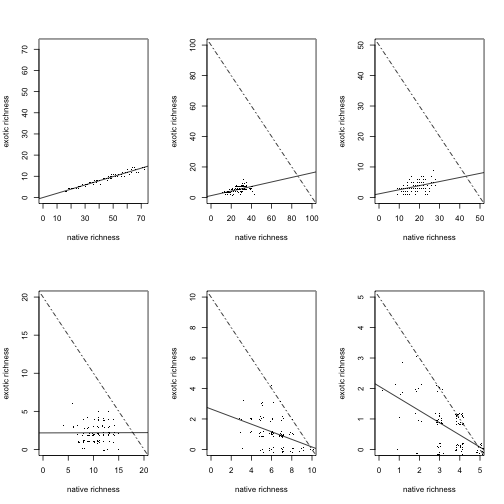

```r
par(mfrow = c(2, 3))
# Graph N=800
plot(output[1, 6, ], output[2, 6, ], pch = ".", xlab = "native richness", ylab = "exotic richness",
    xlim = c(0, max(output[1:2, 6, ])), ylim = c(0, max(output[1:2, 6, ])))

abline(lsfit(output[1, 6, ], output[2, 6, ]))
# least-squares regression line

# Graph N=100
plot(output[1, 5, ], output[2, 5, ], pch = ".", xlab = "native richness", ylab = "exotic richness",
    xlim = c(0, samps[5]), ylim = c(0, samps[5]))

abline(lsfit(output[1, 5, ], output[2, 5, ]))  #least-squares regression line

abline(samps[5], -1, lty = 4)
# data constraint envelope, based on sample size

# Graph N=50
plot(output[1, 4, ], output[2, 4, ], pch = ".", xlab = "native richness", ylab = "exotic richness",
    xlim = c(0, samps[4]), ylim = c(0, samps[4]))

abline(lsfit(output[1, 4, ], output[2, 4, ]))
# least-squares regression line

abline(samps[4], -1, lty = 4)
# data constraint envelope, based on sample size

# Graph N=20
plot(jitter(output[1, 3, ]), jitter(output[2, 3, ]), pch = ".", xlab = "native richness",
    ylab = "exotic richness", xlim = c(0, samps[3]), ylim = c(0, samps[3]))

abline(lsfit(output[1, 3, ], output[2, 3, ]))
# least-squares regression line

abline(samps[3], -1, lty = 4)
# data constraint envelope, based on sample size

# Graph N=10
plot(jitter(output[1, 2, ]), jitter(output[2, 2, ]), pch = ".", xlab = "native richness",
    ylab = "exotic richness", xlim = c(0, samps[2]), ylim = c(0, samps[2]))

abline(lsfit(output[1, 2, ], output[2, 2, ]))
# least-squares regression line

abline(samps[2], -1, lty = 4)
# data constraint envelope, based on sample size

# Graph N=5
plot(jitter(output[1, 1, ]), jitter(output[2, 1, ]), pch = ".", xlab = "native richness",
    ylab = "exotic richness", xlim = c(0, samps[1]), ylim = c(0, samps[1]))

abline(lsfit(output[1, 1, ], output[2, 1, ]))
# least-squares regression line and have a data constraint envelope, based
# on sample size
abline(samps[1], -1, lty = 4)
```

Objective 2:

```r
species <- read.csv("/Users/rebeccakulp/Documents/Classes/2014/Stats II/PermuteSeminar-2014/Week-10/speciescounts.csv",
    head = T)

library(reshape)
```

Sum up invasive and native species to get totals, but need to make sure species are not double counted

```r
sites <- aggregate(Count ~ Site + Origin + Species, data = species, FUN = "sum")

sites$Count <- factor(sites$Count)

sites$count = 1

sites.new <- aggregate(count ~ Site + Origin, data = sites, FUN = "sum")
# does not have zeros for when no invasive/natives present

colnames(sites.new) <- c("Site", "Origin", "value")

site.sp.quad <- cast(sites.new, Origin ~ Site)

site.sp.quad[is.na(site.sp.quad)] <- 0

column.quad <- melt(site.sp.quad, id = c("Site", "Origin"))
```

Correlate the number of exotics and natives

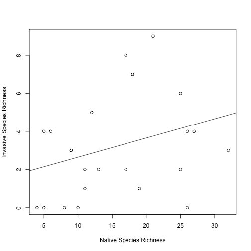

```r
# first need to pull the natives and invasives into two columnes
natives <- subset(column.quad, column.quad$Origin %in% c("N"))

natives$Origin <- factor(natives$Origin)

invasives <- subset(column.quad, column.quad$Origin %in% c("I"))

invasives$Origin <- factor(invasives$Origin)

# now bind the two
data.graph <- cbind(natives[, c(2, 3)], invasives$value)

# graph invasives against natives
plot(invasives$value ~ value, data = data.graph, ylab = "Invasive Species Richness",
    xlab = "Native Species Richness")

data.lm <- lm(invasives$value ~ value, data = data.graph)

abline(data.lm)
```

```r
lm.r <- summary(data.lm)

r.square <- sqrt(lm.r$r.squared)
print(r.square)
```

```
## [1] 0.307
```

```r
s <- lm.r$coefficients[2]
print(s)
```

```
## [1] 0.1008
```

The R squared value is 0.09 (not a good fit at all)-maybe another function will better fit the data, and use this different model to get different statistics to compare to a null distribution. Ye, since we are mimicking Fridley et al. (2004), we will still use the Null distribution of the correlation coefficient and s statistics.